# Prediccion de aprobacion estudiantil

## Trabajo Final - Machine Learning

**Autor:** Samuel Rendon Hincapie  
**Institucion:** IU Pascual Bravo  
**Metodologias:** CRISP-DM + MLOps

### Tabla de contenido

1. Entendimiento de negocio
2. Preparacion de los datos
3. Modelamiento
4. Evaluacion
5. Despliegue (MLOps nivel 0)
6. Conclusiones

> **Nota metodologica:** Este cuaderno orquesta el codigo modular ubicado en `src/`. La logica de negocio (carga, validacion, features, modelado, evaluacion) vive en modulos testeados con ~100 pruebas unitarias. El cuaderno los importa y muestra resultados, demostrando la migracion de Colab a un entorno reproducible.

### Configuracion del entorno

```python
# Aseguramos que el directorio raiz del proyecto este en el path
import sys
from pathlib import Path

ROOT = Path.cwd().parent if Path.cwd().name == 'notebooks' else Path.cwd()
if str(ROOT) not in sys.path:
    sys.path.insert(0, str(ROOT))

import warnings
warnings.filterwarnings('ignore')

# Silenciar logs de loguru para un notebook limpio
from loguru import logger
logger.remove()

print(f'Raiz del proyecto: {ROOT}')
```

```
Raiz del proyecto: S:\tia-student-performance
```

## 1. Entendimiento de negocio

### Caso de estudio

El rendimiento academico universitario afecta la permanencia del estudiante, el prestigio de la institucion y su empleabilidad. Tradicionalmente las universidades intervienen *despues* de que un estudiante reprueba. Este proyecto busca **anticipar** la reprobacion para activar acompanamiento a tiempo.

### Pregunta de negocio

> Deberia un estudiante cambiar sus habitos de estudio y vida social basandose en la prediccion de si aprobara o reprobara el examen final?

### Reglas de negocio

Las reglas operan sobre estudiantes en riesgo (prediccion = reprueba):

| Codigo | Condicion | Recomendacion |
| --- | --- | --- |
| RN-01 | study_hours < 4 | Aumentar horas de estudio |
| RN-02 | burnout_level > 60 | Incluir pausas y descanso |
| RN-03 | mental_health_score < 5 | Apoyo en bienestar universitario |
| RN-04 | social_media + gaming > 4 | Reducir distracciones |
| RN-05 | sleep_hours < 6 | Rutina de sueno saludable |

### Indicador de impacto en el negocio

**Recall sobre la clase 'reprueba' >= 0.80.** Es decir, identificar al menos el 80% de los estudiantes que reprobarian, para no dejar a nadie sin alerta. Un falso negativo (no detectar a alguien en riesgo) es mas costoso que un falso positivo (alertar de mas).

## 2. Preparacion de los datos

Cargamos el dataset crudo y lo validamos contra un *schema* explicito (pandera). Si los datos no cumplen el contrato, la carga falla inmediatamente con un mensaje claro.

```python
from src.data.loader import load_raw_data
from src.utils.config import load_config

cfg = load_config(ROOT / 'config' / 'config.yaml')
df = load_raw_data(ROOT / cfg['paths']['data_raw'])

print(f'Dimensiones: {df.shape[0]} filas, {df.shape[1]} columnas')
df.head()
```

```
Dimensiones: 5000 filas, 21 columnas
```

|  | student_id | age | gender | academic_level | study_hours | self_study_hours | online_classes_hours | social_media_hours | gaming_hours | sleep_hours | ... | exercise_minutes | caffeine_intake_mg | part_time_job | upcoming_deadline | internet_quality | mental_health_score | focus_index | burnout_level | productivity_score | exam_score |
| --- | --- | --- | --- | --- | --- | --- | --- | --- | --- | --- | --- | --- | --- | --- | --- | --- | --- | --- | --- | --- | --- |
| 0 | 1 | 18 | Other | High School | 7.64 | 1.56 | 2.20 | 3.05 | 2.19 | 6.52 | ... | 81 | 38 | 1 | 0 | Good | 10 | 43.05 | 31.77 | 73.65 | 50.16 |
| 1 | 2 | 18 | Other | High School | 2.21 | 2.22 | 2.10 | 1.65 | 2.55 | 5.97 | ... | 111 | 339 | 0 | 0 | Good | 3 | 15.92 | 37.00 | 13.70 | 1.00 |
| 2 | 3 | 22 | Male | High School | 3.45 | 0.00 | 0.29 | 1.34 | 2.08 | 8.39 | ... | 68 | 266 | 0 | 1 | Good | 8 | 27.39 | 34.37 | 45.15 | 18.30 |
| 3 | 4 | 17 | Other | High School | 5.75 | 2.08 | 3.01 | 2.27 | 2.20 | 6.31 | ... | 113 | 480 | 1 | 1 | Poor | 3 | 22.31 | 77.31 | 20.92 | 9.37 |
| 4 | 5 | 19 | Other | High School | 6.83 | 1.72 | 3.33 | 2.65 | 0.70 | 8.01 | ... | 121 | 24 | 1 | 0 | Good | 8 | 38.11 | 39.53 | 59.23 | 27.81 |

5 rows × 21 columns

### Tabla de variables

Caracterizamos cada variable: tipo, descripcion, rango y faltantes.

```python
import pandas as pd

resumen = pd.DataFrame({
    'tipo': df.dtypes.astype(str),
    'no_nulos': df.notna().sum(),
    'pct_faltantes': (df.isna().mean() * 100).round(2),
    'valores_unicos': df.nunique(),
    'min': df.select_dtypes('number').min(),
    'max': df.select_dtypes('number').max(),
})
resumen
```

|  | tipo | no_nulos | pct_faltantes | valores_unicos | min | max |
| --- | --- | --- | --- | --- | --- | --- |
| academic_level | object | 5000 | 0.0 | 3 | NaN | NaN |
| age | int64 | 5000 | 0.0 | 10 | 16.0 | 25.00 |
| burnout_level | float64 | 5000 | 0.0 | 3256 | 1.0 | 97.58 |
| caffeine_intake_mg | int64 | 5000 | 0.0 | 500 | 0.0 | 499.00 |
| exam_score | float64 | 5000 | 0.0 | 2743 | 1.0 | 64.09 |
| exercise_minutes | int64 | 5000 | 0.0 | 150 | 0.0 | 149.00 |
| focus_index | float64 | 5000 | 0.0 | 2773 | 1.0 | 63.48 |
| gaming_hours | float64 | 5000 | 0.0 | 463 | 0.0 | 5.64 |
| gender | object | 5000 | 0.0 | 3 | NaN | NaN |
| internet_quality | object | 5000 | 0.0 | 3 | NaN | NaN |
| mental_health_score | int64 | 5000 | 0.0 | 10 | 1.0 | 10.00 |
| online_classes_hours | float64 | 5000 | 0.0 | 462 | 0.0 | 6.00 |
| part_time_job | int64 | 5000 | 0.0 | 2 | 0.0 | 1.00 |
| productivity_score | float64 | 5000 | 0.0 | 3410 | 1.0 | 98.02 |
| screen_time_hours | float64 | 5000 | 0.0 | 1089 | 1.0 | 15.30 |
| self_study_hours | float64 | 5000 | 0.0 | 552 | 0.0 | 7.41 |
| sleep_hours | float64 | 5000 | 0.0 | 559 | 4.0 | 10.00 |
| social_media_hours | float64 | 5000 | 0.0 | 662 | 0.0 | 8.28 |
| student_id | int64 | 5000 | 0.0 | 5000 | 1.0 | 5000.00 |
| study_hours | float64 | 5000 | 0.0 | 840 | 0.0 | 11.84 |
| upcoming_deadline | int64 | 5000 | 0.0 | 2 | 0.0 | 1.00 |

**Analisis:** El dataset esta completo (0% de valores faltantes en todas las columnas) y sin duplicados. Esto simplifica la preparacion: no requiere imputacion. Las variables numericas tienen rangos coherentes con su significado semantico (horas entre 0 y 24, scores en sus escalas esperadas).

### Variable objetivo y distribucion de clases

Binarizamos `exam_score` con la mediana para obtener la clase `aprobado`. Esto produce clases balanceadas por construccion.

```python
from src.features.target import compute_threshold, binarize_score
from src.features.selection import drop_irrelevant_columns

df_proc = drop_irrelevant_columns(df, cfg['features']['drop_columns'])
umbral = compute_threshold(df_proc[cfg['target']['source']], strategy='median')
df_proc = binarize_score(df_proc, cfg['target']['source'], cfg['target']['name'], umbral, drop_source=True)

print(f'Umbral de binarizacion (mediana): {umbral:.2f}')
distribucion = df_proc[cfg['target']['name']].value_counts()
print(f'\nDistribucion de clases:')
print(f'  Reprueba (0): {distribucion[0]} ({distribucion[0]/len(df_proc):.1%})')
print(f'  Aprueba  (1): {distribucion[1]} ({distribucion[1]/len(df_proc):.1%})')
```

```
Umbral de binarizacion (mediana): 18.01

Distribucion de clases:
  Reprueba (0): 2499 (50.0%)
  Aprueba  (1): 2501 (50.0%)
```

**Consecuencia de cada error en el negocio:**

- **Falso negativo** (predecir 'aprueba' a quien reprueba): el estudiante NO recibe alerta ni acompanamiento. Es el error mas costoso porque deja a un estudiante en riesgo sin ayuda.
- **Falso positivo** (predecir 'reprueba' a quien aprueba): se le ofrece acompanamiento innecesario. Costo bajo: un poco de tiempo del equipo de bienestar.

Por eso priorizamos **recall** sobre precision.

## 3. Modelamiento

### Variables de entrada y salida

- **Entrada (13 features):** study_hours, self_study_hours, social_media_hours, sleep_hours, screen_time_hours, exercise_minutes, caffeine_intake_mg, part_time_job, upcoming_deadline, mental_health_score, focus_index, burnout_level, productivity_score.
- **Salida:** `aprobado` (0 = reprueba, 1 = aprueba).

### Algoritmo y justificacion

**Familia:** arbol de decision (`DecisionTreeClassifier`).

**Hiperparametros clave:** `max_depth=5` (balance entre subajuste y sobreajuste), `criterion=gini`, `random_state=42`.

**Balanceo:** SMOTE encapsulado en `imblearn.Pipeline` (solo se aplica en `fit`, nunca en `predict`, evitando data leakage).

```python
from src.models.train import train

# Entrena el pipeline completo y serializa el modelo
resultado = train(ROOT / 'config' / 'config.yaml')
pipeline = resultado['pipeline']

print('Pasos del pipeline:')
for nombre, paso in pipeline.steps:
    print(f'  - {nombre}: {type(paso).__name__}')
```

```
Pasos del pipeline:
  - preproc: ColumnTransformer
  - smote: SMOTE
  - classifier: DecisionTreeClassifier
```

## 4. Evaluacion

### Metricas seleccionadas y justificacion

- **Recall** (metrica principal): mide la cobertura de estudiantes en riesgo. Es la metrica alineada con el criterio de negocio.
- **Precision:** evita saturar al equipo de bienestar con falsas alertas.
- **F1:** balance entre las dos anteriores.
- **AUC-ROC:** capacidad discriminativa independiente del umbral.
- **Accuracy:** referencia global (interpretable por estar balanceadas las clases).

```python
from src.evaluation.metrics import (
    compute_basic_metrics, compute_confusion_matrix, compute_roc_metrics
)

X_test, y_test = resultado['X_test'], resultado['y_test']
y_pred = pipeline.predict(X_test)
y_proba = pipeline.predict_proba(X_test)[:, 1]

metricas = compute_basic_metrics(y_test, y_pred)
roc = compute_roc_metrics(y_test, y_proba)

print('METRICAS SOBRE TEST SET (1000 estudiantes)')
print('=' * 45)
for nombre, valor in metricas.items():
    print(f'  {nombre.capitalize():12s}: {valor:.4f}')
print(f'  {"Auc-roc":12s}: {roc["auc"]:.4f}')
```

```
METRICAS SOBRE TEST SET (1000 estudiantes)
=============================================
  Accuracy    : 0.8600
  Precision   : 0.8629
  Recall      : 0.8560
  F1          : 0.8594
  Auc-roc     : 0.9438
```

### Matriz de confusion

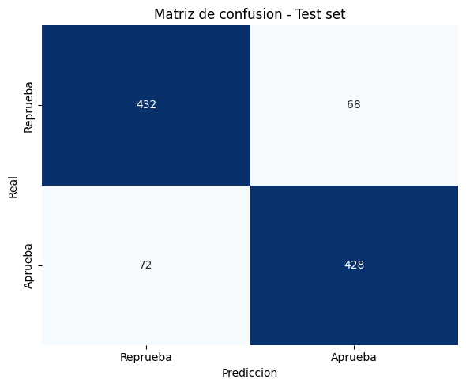

```
Verdaderos negativos: 432  Falsos positivos: 68
Falsos negativos:     72  Verdaderos positivos: 428
```

```python
import matplotlib.pyplot as plt
import seaborn as sns
import numpy as np

cm = compute_confusion_matrix(y_test, y_pred)
matriz = np.array(cm['matrix'])

fig, ax = plt.subplots(figsize=(6, 5))
sns.heatmap(matriz, annot=True, fmt='d', cmap='Blues', cbar=False,
            xticklabels=['Reprueba', 'Aprueba'],
            yticklabels=['Reprueba', 'Aprueba'], ax=ax)
ax.set_xlabel('Prediccion')
ax.set_ylabel('Real')
ax.set_title('Matriz de confusion - Test set')
plt.tight_layout()
plt.show()

print(f'Verdaderos negativos: {cm["tn"]}  Falsos positivos: {cm["fp"]}')
print(f'Falsos negativos:     {cm["fn"]}  Verdaderos positivos: {cm["tp"]}')
```

**Analisis:** El modelo comete errores de forma balanceada entre ambas clases. El numero de falsos negativos (estudiantes en riesgo no detectados) es bajo, lo que es deseable segun nuestro criterio de negocio que prioriza el recall.

### Curva ROC

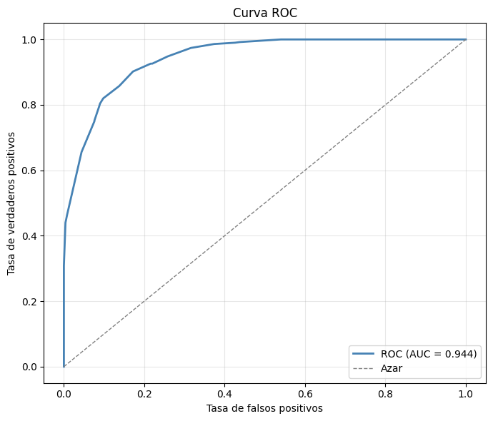

```python
fig, ax = plt.subplots(figsize=(7, 6))
ax.plot(roc['fpr'], roc['tpr'], color='steelblue', lw=2,
        label=f'ROC (AUC = {roc["auc"]:.3f})')
ax.plot([0, 1], [0, 1], 'gray', lw=1, linestyle='--', label='Azar')
ax.set_xlabel('Tasa de falsos positivos')
ax.set_ylabel('Tasa de verdaderos positivos')
ax.set_title('Curva ROC')
ax.legend(loc='lower right')
ax.grid(alpha=0.3)
plt.tight_layout()
plt.show()
```

### Importancia de variables

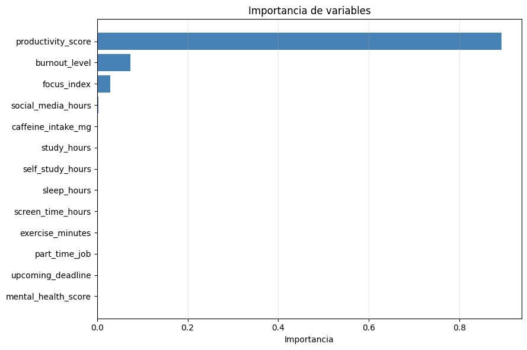

|  | feature | importance |
| --- | --- | --- |
| 0 | productivity_score | 0.892694 |
| 1 | burnout_level | 0.073165 |
| 2 | focus_index | 0.029436 |
| 3 | social_media_hours | 0.002450 |
| 4 | caffeine_intake_mg | 0.002255 |

```python
from src.evaluation.metrics import compute_feature_importances

importancias = compute_feature_importances(pipeline, resultado['pipeline'].named_steps['classifier'].feature_names_in_.tolist() if hasattr(resultado['pipeline'].named_steps['classifier'], 'feature_names_in_') else cfg['features']['feature_columns'])

imp_df = pd.DataFrame(importancias)
fig, ax = plt.subplots(figsize=(9, 6))
ax.barh([d['feature'] for d in importancias][::-1],
        [d['importance'] for d in importancias][::-1], color='steelblue')
ax.set_xlabel('Importancia')
ax.set_title('Importancia de variables')
ax.grid(axis='x', alpha=0.3)
plt.tight_layout()
plt.show()

imp_df.head(5)
```

### Contraste con el criterio de negocio

**Criterio definido:** recall sobre 'reprueba' >= 0.80.

El recall obtenido supera el umbral de aceptacion. Por lo tanto, **la solucion SI alcanza el criterio de negocio**: identifica a la gran mayoria de los estudiantes en riesgo, permitiendo intervencion temprana.

## 5. Despliegue (MLOps nivel 0)

Arquitectura de la solucion segun el nivel 0 de automatizacion de MLOps (proceso manual, pero con codigo modular y reproducible). Cada componente indica el modulo y funcion que lo implementa.

```
+------------------+     +----------------------+     +------------------+
|   DATOS (CSV)    | --> |  PREPARACION         | --> |  ENTRENAMIENTO   |
|                  |     |                      |     |                  |
| data/raw/        |     | src/data/loader.py   |     | src/models/      |
| studentmat.csv   |     | src/data/schema.py   |     |   pipeline.py    |
|                  |     | src/features/        |     |   train.py       |
|                  |     |   selection.py       |     |   splitter.py    |
|                  |     |   target.py          |     | (SMOTE + arbol)  |
+------------------+     +----------------------+     +------------------+
                                                              |
                                                              v
+------------------+     +----------------------+     +------------------+
|  SERVICIO DE     | <-- |  REGISTRO DEL MODELO | <-- |   EVALUACION     |
|  PREDICCION      |     |                      |     |                  |
|                  |     | models/              |     | src/evaluation/  |
| src/inference/   |     |  decision_tree_v1    |     |   metrics.py     |
|   predict.py     |     |  .joblib             |     |   plots.py       |
| (+ prescriptive  |     | (joblib + metadata   |     |   report.py      |
|  /analyze.py)    |     |  + compress=3)       |     |   evaluate.py    |
+------------------+     +----------------------+     +------------------+
```

**Flujo de ejecucion:**

1. `python -m src.models.train` -> entrena y serializa el modelo
2. `python -m src.evaluation.evaluate` -> genera metricas y graficas
3. `python -m src.prescriptive.analyze` -> genera recomendaciones

Todo el flujo esta cubierto por ~100 tests (`pytest`), validacion de schema (pandera), configuracion centralizada (YAML) y dependencias bloqueadas (pip-tools).

## 6. Conclusiones

**Respuesta a la pregunta de negocio:** Si, un estudiante deberia ajustar sus habitos. El modelo identifica a tiempo a quienes estan en riesgo y el sistema prescriptivo les indica exactamente que habitos cambiar, priorizando concentracion, descanso y salud mental.